# Pseudobulk analysis

Steven Foltz and Jaclyn Taroni

2024

This notebook uses a medulloblastoma subgroup prediction model trained on bulk data to predict the subgroup of pseudobulk samples. Pseudobulk samples were generated from single-cell experiments by averaging gene expression across all cells on a per gene level. k-Top Scoring Pairs (kTSP) and random forest (RF) models were trained using bulk gene expression data (bulk array and RNA-seq) in `analysis_notebooks/baseline_models.Rmd`. Here, we analyze the kTSP, RF, and medulloPackage ([Rathi, et al.](https://doi.org/10.1371/journal.pcbi.1008263)) predictions on pseudobulk samples generated in `predict/predict_pseudobulk_and_single_cells.R`.

We are using scRNA-seq data associated with the following publications:

- [Hovestadt, et al.](https://www.nature.com/articles/s41586-019-1434-6), which is Smart-seq2 dataset
- [Riemondy, et al.](https://doi.org/10.1093/neuonc/noab135), which is a 10X Genomics dataset

# Setup

```r
set.seed(8222)
```

## Libraries

```r
# Load libraries
source(here::here("utils/color_schemes.R"))
source(here::here("utils/modeling.R"))
library(patchwork)
```

## Directories and files

```r
# Directories
processed_data_dir <- here::here("processed_data", "pseudobulk")
plots_dir <- here::here("plots")
plots_data_dir <- here::here(plots_dir, "data")

# Input files
pseudobulk_metadata_filepath <- here::here(processed_data_dir, "pseudobulk_metadata.tsv")
pseudobulk_plot_data_filepath <- here::here(plots_data_dir, "pseudobulk_test_predictions.tsv")

# Output files
rule_based_plot_filepath <- here::here("plots/single_cell_pseudobulk_rule_based_models.pdf")
confusion_matrix_plot_filepath <- here::here("plots/single_cell_pseudobulk_medullopackage_confusion_matrix.pdf")
```

## Custom function

A custom function for returning a one-row data frame with classifier metrics. This is not intended to be used outside the context of this notebook.

```r
calculate_metrics <- function(df, subgroup_labels) {

  # Calculate the Kappa, Total Accuracy, and Balanced Accuracy per class metrics
  # from a set of predictions
  #
  # Inputs
  #  df: data frame with "predicted_labels", true "subgroup" labels,
  #      a "study" column, and a "model_type" column
  #  subgroup_labels: vector of possible sample labels
  #                   (e.g., c("G3","G4","SHH","WNT"))
  #
  # Outputs
  #  Data frame of model metrics

  cm <- calculate_confusion_matrix(predicted_labels = df$predicted_labels,
                                   true_labels = df$subgroup,
                                   labels = mb_subgroups)
  perf_df <- data.frame(
    study = unique(df$study),
    model_type = unique(df$model_type),
    kappa = cm$overall[["Kappa"]],
    total_accuracy = cm$overall[["Accuracy"]],
    t(cm$byClass[, "Balanced Accuracy"])
  )

  return(perf_df)

}
```

## Read in data

```r
# Read in data
pseudobulk_metadata_df <- readr::read_tsv(pseudobulk_metadata_filepath,
                                          show_col_types = FALSE) |>
  dplyr::mutate(sample_accession = title)

pseudobulk_plot_df <- readr::read_tsv(pseudobulk_plot_data_filepath,
                                      show_col_types = FALSE)

# The labels we will use throughout
mb_subgroups <- c("G3", "G4", "SHH", "WNT")
```

# Plot pseudobulk predictions

## Prepare data for individual models

```r
# We will plot the scores, which range from 0 to 1, as individual points for
# the kTSP models
ktsp_pseudobulk_plot_df <- pseudobulk_plot_df |>
  dplyr::filter(model_type == "kTSP (w)") |>
  dplyr::select(-best.fit) |>
  tidyr::pivot_longer(cols = all_of(mb_subgroups),
                      names_to = "predicted_subgroup")

# The "scores" for RF models are probabilities, given the way we train RF
# models, so we only need to get this into long format for plotting
rf_pseudobulk_plot_df <- pseudobulk_plot_df |>
  dplyr::filter(model_type == "RF (w)") |>
  dplyr::select(-best.fit) |>
  tidyr::pivot_longer(cols = all_of(mb_subgroups),
                      names_to = "predicted_subgroup")

# The medulloPackage method outputs a p-value associated with a best fit
# class label -- we will only consider the predicted labels themselves
mp_pseudobulk_plot_df <- pseudobulk_plot_df |>
  dplyr::filter(model_type == "medulloPackage") |>
  dplyr::select(sample_accession,
                model_type,
                study,
                subgroup,
                predicted_labels = best.fit)
```

## Stacked barplots for RF models

Random forest models output a probability for each subgroup – these values sum to 1. So, we can use a stacked barplot to display the results for each dataset separately.

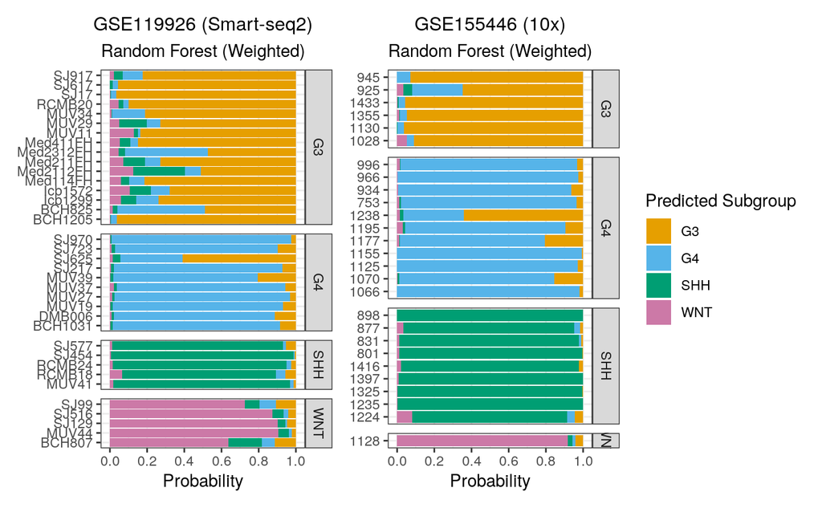

```r
rf_smartseq_barplot_object <- rf_pseudobulk_plot_df |>
  dplyr::filter(study == "GSE119926") |>
  ggplot2::ggplot(ggplot2::aes(y = sample_accession,
                               x = value,
                               fill = predicted_subgroup)) +
  ggplot2::geom_col() +
  ggplot2::scale_x_continuous(breaks = scales::pretty_breaks()) +
  ggplot2::scale_fill_manual(values = subgroup_colors) +
  ggplot2::facet_grid(rows = ggplot2::vars(subgroup),
                      scales= "free_y",
                      space = "free_y") +
  ggplot2::labs(x = "Probability",
                y = NULL,
                fill = "Predicted Subgroup",
                title = "GSE119926 (Smart-seq2)",
                subtitle = "Random Forest (Weighted)") +
  ggplot2::theme_bw() +
  ggplot2::theme(plot.title = ggplot2::element_text(hjust = 0.5,
                                                    size = 12),
                 plot.subtitle = ggplot2::element_text(hjust = 0.5))

rf_10x_barplot_object <- rf_pseudobulk_plot_df |>
  dplyr::filter(study == "GSE155446") |>
  ggplot2::ggplot(ggplot2::aes(y = sample_accession,
                               x = value,
                               fill = predicted_subgroup)) +
  ggplot2::geom_col() +
  ggplot2::scale_x_continuous(breaks = scales::pretty_breaks()) +
  ggplot2::scale_fill_manual(values = subgroup_colors) +
  ggplot2::facet_grid(rows = ggplot2::vars(subgroup),
                      scales= "free_y",
                      space = "free_y") +
  ggplot2::labs(x = "Probability",
                y = NULL,
                fill = "Predicted Subgroup",
                title = "GSE155446 (10x)",
                subtitle = "Random Forest (Weighted)") +
  ggplot2::theme_bw() +
  ggplot2::theme(plot.title = ggplot2::element_text(hjust = 0.5,
                                                    size = 12),
                 plot.subtitle = ggplot2::element_text(hjust = 0.5))

rf_smartseq_barplot_object +
  rf_10x_barplot_object +
  plot_layout(guides = "collect")
```

## Plot individual scores with points for kTSP models

kTSP models assign a score – bounded from zero to one – to each subgroup. We will plot the scores for each subtype as an individual point.

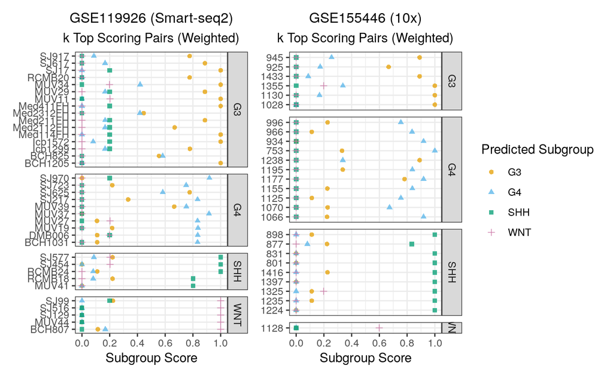

```r
ktsp_smartseq_points_object <- ktsp_pseudobulk_plot_df |>
  dplyr::filter(study == "GSE119926") |>
  ggplot2::ggplot(ggplot2::aes(y = sample_accession,
                               x = value,
                               color = predicted_subgroup,
                               shape = predicted_subgroup)) +
  ggplot2::geom_point(alpha = 0.75) +
  ggplot2::scale_x_continuous(breaks = scales::pretty_breaks()) +
  ggplot2::scale_color_manual(values = subgroup_colors) +
  ggplot2::facet_grid(rows = ggplot2::vars(subgroup),
                      scales= "free_y",
                      space = "free_y") +
  ggplot2::labs(x = "Subgroup Score",
                y = NULL,
                color = "Predicted Subgroup",
                shape = "Predicted Subgroup",
                title = "GSE119926 (Smart-seq2)",
                subtitle = "k Top Scoring Pairs (Weighted)") +
  ggplot2::theme_bw() +
  ggplot2::theme(plot.title = ggplot2::element_text(hjust = 0.5,
                                                    size = 12),
                 plot.subtitle = ggplot2::element_text(hjust = 0.5))

ktsp_10x_points_object <- ktsp_pseudobulk_plot_df |>
  dplyr::filter(study == "GSE155446") |>
  ggplot2::ggplot(ggplot2::aes(y = sample_accession,
                               x = value,
                               color = predicted_subgroup,
                               shape = predicted_subgroup)) +
  ggplot2::geom_point(alpha = 0.75) +
  ggplot2::scale_x_continuous(breaks = scales::pretty_breaks()) +
  ggplot2::scale_color_manual(values = subgroup_colors) +
  ggplot2::facet_grid(rows = ggplot2::vars(subgroup),
                      scales= "free_y",
                      space = "free_y") +
  ggplot2::labs(x = "Subgroup Score",
                y = NULL,
                color = "Predicted Subgroup",
                shape = "Predicted Subgroup",
                fill = "Predicted Subgroup",
                title = "GSE155446 (10x)",
                subtitle = "k Top Scoring Pairs (Weighted)") +
  ggplot2::theme_bw() +
  ggplot2::theme(plot.title = ggplot2::element_text(hjust = 0.5,
                                                    size = 12),
                 plot.subtitle = ggplot2::element_text(hjust = 0.5))

ktsp_smartseq_points_object +
  ktsp_10x_points_object +
  plot_layout(guides = "collect")
```

## Save a combined figure for the rule-based models

```r
combined_rule_based_plots <-
  (rf_smartseq_barplot_object +
     ktsp_smartseq_points_object +
     rf_10x_barplot_object +
     ktsp_10x_points_object) +
  plot_layout(guides = "collect")
```

|  | t | l | b | r |
| --- | --- | --- | --- | --- |
| 1: | 1 | 1 | 1 | 1 |
| 2: | 2 | 1 | 2 | 1 |
| 3: | 1 | 2 | 1 | 2 |
| 4: | 2 | 2 | 2 | 2 |

```r
ggplot2::ggsave(file = rule_based_plot_filepath,
                plot = combined_rule_based_plots,
                height = 11,
                width = 8.5,
                units = "in")
```

## Plot confusion matrix for medulloPackage models

### Calculate confusion matrices

```r
# We will calculate the confusion matrices separately for each study
mp_smartseq_df <- mp_pseudobulk_plot_df |>
  dplyr::filter(study == "GSE119926")
mp_10x_df <- mp_pseudobulk_plot_df |>
  dplyr::filter(study == "GSE155446")

# Make Smart-seq2 confusion matrix
mp_smartseq_perf <- calculate_confusion_matrix(
  predicted_labels = mp_smartseq_df$predicted_labels,
  true_labels = mp_smartseq_df$subgroup,
  labels = mb_subgroups
)
# Make 10x dataset confusion matrix
mp_10x_perf <- calculate_confusion_matrix(
  predicted_labels = mp_10x_df$predicted_labels,
  true_labels = mp_10x_df$subgroup,
  labels = mb_subgroups
)
```

### Plotting tile plots

Use a custom palette that goes from white to red.

```r
custom_continuous_pal <- grDevices::colorRampPalette(c("white", "red"))
```

Create tile plots for each dataset separately.

```r
# Tile plot (i.e., heatmap) for Smart-seq2 dataset
mp_smartseq_cm_object <- mp_smartseq_perf$table |>
  as.data.frame() |>
  dplyr::mutate(Prediction = factor(Prediction,
                                    levels = mb_subgroups[4:1]),
                Reference = factor(Reference,
                                   levels = mb_subgroups[1:4])) |>
  ggplot2::ggplot(ggplot2::aes(x = Reference,
                               y = Prediction,
                               fill = Freq)) +
  ggplot2::geom_tile(color = "#000000") +
  ggplot2::geom_text(ggplot2::aes(label = Freq),
                     color = "#000000") +
  ggplot2::labs(title = "GSE119926 (Smart-seq2)",
                subtitle = "medulloPackage") +
  ggplot2::scale_fill_gradientn(colours = custom_continuous_pal(100),
                                limits = c(0, max(mp_smartseq_perf$table))) +
  ggplot2::theme_bw() +
  ggplot2::theme(plot.title = ggplot2::element_text(hjust = 0.5,
                                                    size = 12),
                 plot.subtitle = ggplot2::element_text(hjust = 0.5)) +
  ggplot2::guides(fill = "none")  +
  ggplot2::coord_fixed()

# Tile plot (i.e., heatmap) for 10x dataset
mp_10x_cm_object <- mp_10x_perf$table |>
  as.data.frame() |>
  dplyr::mutate(Prediction = factor(Prediction,
                                    levels = mb_subgroups[4:1]),
                Reference = factor(Reference,
                                   levels = mb_subgroups[1:4])) |>
  ggplot2::ggplot(ggplot2::aes(x = Reference,
                               y = Prediction,
                               fill = Freq)) +
  ggplot2::geom_tile(color = "#000000") +
  ggplot2::geom_text(ggplot2::aes(label = Freq),
                     color = "#000000") +
  ggplot2::labs(title = "GSE155446 (10x)",
                subtitle = "medulloPackage") +
  ggplot2::scale_fill_gradientn(colours = custom_continuous_pal(100),
                                limits = c(0, max(mp_10x_perf$table))) +
  ggplot2::theme_bw() +
  ggplot2::theme(plot.title = ggplot2::element_text(hjust = 0.5,
                                                    size = 12),
                 plot.subtitle = ggplot2::element_text(hjust = 0.5)) +
  ggplot2::guides(fill = "none") +
  ggplot2::coord_fixed()
```

Combine the confusion matrix plots into one multipanel plot.

```r
confusion_matrix_plot <- (mp_smartseq_cm_object / mp_10x_cm_object)
```

|  | t | l | b | r |
| --- | --- | --- | --- | --- |
| 1: | 1 | 1 | 1 | 1 |
| 2: | 1 | 2 | 1 | 2 |

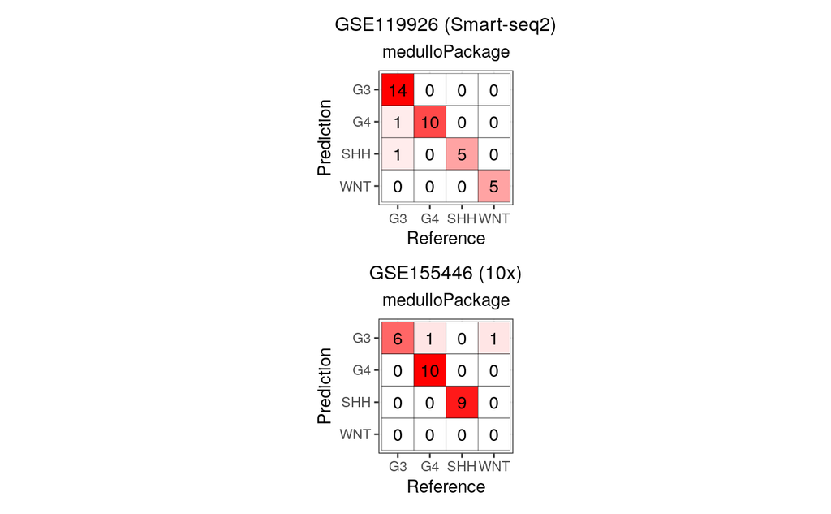

```r
confusion_matrix_plot
```

Save to file.

```r
ggplot2::ggsave(file = confusion_matrix_plot_filepath,
                plot = confusion_matrix_plot,
                height = 11,
                width = 8.5,
                units = "in")
```

# Metrics

## Get the predicted labels for metrics calculation

```r
df_for_metrics <- pseudobulk_plot_df |>
  # For both rule-based models, the subgroup with the highest score or
  # or probability will be the label that gets assigned
  dplyr::filter(model_type %in% c("RF (w)",
                                  "kTSP (w)")) |>
  dplyr::rowwise() |>
  dplyr::mutate(
    predicted_labels = c("G3",
                         "G4",
                         "SHH",
                         "WNT")[which.max(c(G3, G4, SHH, WNT))]
  ) |>
  dplyr::ungroup() |>
  # Remove everything except the sample, study, classifier, and both sets of
  # labels (predicted and true)
  dplyr::select(-G3,
                -G4,
                -SHH,
                -WNT,
                -best.fit) |>
  # Add back the medulloPackage rows
  dplyr::bind_rows(mp_smartseq_df,
                   mp_10x_df)
```

## Create a table of metrics for all model-experiment pairs

```r
# Create a data.frame that contains all pairs of study and model to be used
# to calculate metrics separate
model_experiment_pairs_df <- expand.grid(
  c("GSE119926", "GSE155446"),
  c("kTSP (w)", "RF (w)", "medulloPackage")
) |>
  dplyr::rename(dataset = Var1,
                classifier = Var2)
```

```r
model_experiment_pairs_df |>
  # For each model type-experiment pair, calculate performance metrics and
  # then combine into a single data frame
  purrr::pmap(\(dataset, classifier)
                calculate_metrics(
                  df_for_metrics |>
                    dplyr::filter(study == dataset,
                                  model_type == classifier),
                  subgroup_labels = mb_subgroups
                )
              ) |>
  purrr::list_rbind() |>
  # Rename the balanced accuracy columns to be something a bit nicer!
  dplyr::rename(
    G3_balanced_accuracy = `Class..G3`,
    G4_balanced_accuracy = `Class..G4`,
    SHH_balanced_accuracy = `Class..SHH`,
    WNT_balanced_accuracy = `Class..WNT`
  )
```

| study | model_type | kappa | total_accuracy | G3_balanced_accuracy | G4_balanced_accuracy | SHH_balanced_accuracy | WNT_balanced_accuracy |
| --- | --- | --- | --- | --- | --- | --- | --- |
| GSE119926 | kTSP (w) | 0.9191011 | 0.9444444 | 0.9437500 | 0.9307692 | 1.000000 | 1.0 |
| GSE155446 | kTSP (w) | 0.9454545 | 0.9629630 | 0.9761905 | 0.9545455 | 1.000000 | 1.0 |
| GSE119926 | RF (w) | 0.9592760 | 0.9722222 | 0.9750000 | 0.9500000 | 1.000000 | 1.0 |
| GSE155446 | RF (w) | 0.9454545 | 0.9629630 | 0.9761905 | 0.9545455 | 1.000000 | 1.0 |
| GSE119926 | medulloPackage | 0.9206174 | 0.9444444 | 0.9375000 | 0.9807692 | 0.983871 | 1.0 |
| GSE155446 | medulloPackage | 0.8897959 | 0.9259259 | 0.9523810 | 0.9545455 | 1.000000 | 0.5 |

The models perform pretty similarly across experiments, with the exception of WNT balanced accuracy of the `medulloPackage` model in the 10X dataset.

# Misclassified samples

Let’s look at (the few) misclassified samples and see if they are the same across classifiers.

```r
df_for_metrics |>
  dplyr::filter(predicted_labels != subgroup) |>
  dplyr::arrange(study, sample_accession)
```

| sample_accession | model_type | study | subgroup | predicted_labels |
| --- | --- | --- | --- | --- |
| BCH825 | kTSP (w) | GSE119926 | G3 | G4 |
| BCH825 | medulloPackage | GSE119926 | G3 | G4 |
| Icb1572 | medulloPackage | GSE119926 | G3 | SHH |
| SJ625 | kTSP (w) | GSE119926 | G4 | G3 |
| SJ625 | RF (w) | GSE119926 | G4 | G3 |
| 1128 | medulloPackage | GSE155446 | WNT | G3 |
| 1238 | kTSP (w) | GSE155446 | G4 | G3 |
| 1238 | RF (w) | GSE155446 | G4 | G3 |
| 1238 | medulloPackage | GSE155446 | G4 | G3 |

For the pair-based classifiers, the misses are all between G3 and G4. If we review the plots earlier in the notebook, we see that these are generally samples with a “mix” of G3 and G4 scores. It is worth following up on these samples by examining the individual cell label predictions, which we are able to do using these models.

It is interesting that `medulloPackage` misclassifies a G3 sample as SHH in the Smart-seq2 dataset and a WNT sample as G3 in the 10X dataset, which we also saw earlier when plotting the confusion matrices.